# **TP : Réseau de Neurones**

Réalisé par:

- EL MOUDDEN Aya
- IMAD Aymen
- ZMIR Yassamine
- MOUTAOUAFFIQ Meryam

***Les problèmes 1 et 2 sont dans le fichier PDF joint à ce fichier .ipynb.***

# Probléme II: méthode suplémentaire (autre méthode)

L'idée consiste à classifier les points rouges et bleus en utilisant leur distance par rapport au barycentre des clusters (nuages de points). Chaque nuage de points (rouge ou bleu) est représenté par son barycentre, calculé comme la moyenne des coordonnées des points qui le composent. Pour classer un point donné, on calcule sa distance à chacun des barycentres, et il est attribué à la classe du barycentre le plus proche. Cette méthode peut être vue comme un réseau de neurones simple, où la première couche calcule les distances aux barycentres et la couche de sortie compare ces distances pour prendre une décision. Si la distance au barycentre rouge est inférieure à celle au barycentre bleu, le point est classé comme rouge, et inversement. Cette approche est efficace pour des données bien regroupées dans l’espace, et elle peut être généralisée à plusieurs barycentres pour traiter des clusters supplémentaires.

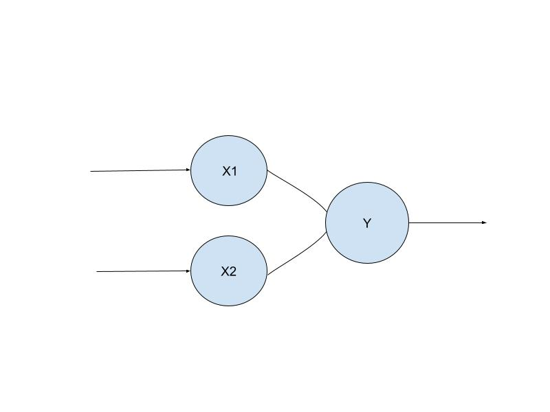

Soit $X_1$ et $X_2$ les coordonnées du point (respectivement l'abscisse et l'ordonnée), et $Y$ le minimum des distances entre ce point et les 4 barycentres.  
Pour éviter que la fonction d'activation devienne non linéaire, on peut utiliser la **distance de Manhattan** pour mesurer les distances.

La distance de Manhattan entre deux points $(x_1, x_2)$et $(b_1, b_2)$ est définie comme suit :

$ \text{dist}((x_1, x_2), (b_1, b_2)) = |x_1 - b_1| + |x_2 - b_2| $

Cette métrique garantit une comparaison cohérente des distances tout en évitant une complexité inutile dans le modèle.

# Probléme III: regression logistique.

- Soit une variable binaire $Y \sim B(p)$ que l'on cherche à expliquer à travers une variable quantitative continue (X).
- On suppose que :
  - $X \mid Y = 1 \sim \mathcal{N}(\mu_1, \sigma^2)$
  - $X \mid Y = 0 \sim \mathcal{N}(\mu_2, \sigma^2)$

# question 1

La densité marginale $ f_X(x) $ est une **distribution de mélange gaussien**, obtenue en pondérant les densités conditionnelles par les probabilités des classes $ Y $ :

$ f_X(x) = P(Y=1) f_{X|Y=1}(x) + P(Y=0) f_{X|Y=0}(x). $

## Densités conditionnelles

La densité d’une variable suivant une loi normale $ \mathcal{N}(\mu, \sigma^2) $ est donnée par :

$ f_{X|Y=i}(x) = \frac{1}{\sqrt{2\pi} \sigma} \exp\left(-\frac{(x - \mu_i)^2}{2\sigma^2}\right) $. $ i \in \{0,1\} $

## Fonction de densité marginale

Substituons les expressions des densités conditionnelles dans l’équation de $ f_X(x) $ :

$ f_X(x) = p \cdot f_{X|Y=1}(x) + (1 - p) \cdot f_{X|Y=0}(x). $

En développant :

$ f_X(x) = p \cdot \frac{1}{\sqrt{2\pi} \sigma} \exp\left(-\frac{(x - \mu_1)^2}{2\sigma^2}\right) + (1 - p) \cdot \frac{1}{\sqrt{2\pi} \sigma} \exp\left(-\frac{(x - \mu_0)^2}{2\sigma^2}\right). $

## Conclusion

La densité marginale de ( X ), appelée **distribution de mélange gaussien**, est donnée par :

$ f_X(x) = \frac{p}{\sqrt{2\pi} \sigma} \exp\left(-\frac{(x - \mu_1)^2}{2\sigma^2}\right) + \frac{1 - p}{\sqrt{2\pi} \sigma} \exp\left(-\frac{(x - \mu_0)^2}{2\sigma^2}\right). $

Cela correspond à une somme pondérée de deux densités normales, où les poids sont $ p $ et $ 1-p $.

# Question 2:

### Calcul de la probabilité conditionnelle $ p(x) = P(Y = 1 \mid X = x) $

#### Rappel du théorème de Bayes

La probabilité conditionnelle est donnée par :

$ P(Y = 1 \mid X = x) = \frac{P(X = x \mid Y = 1) P(Y = 1)}{P(X = x)}. $

La densité conditionnelle ( P(X = x \mid Y = 1) ) suit une loi normale :

$ f_{X \mid Y=1}(x) = \frac{1}{\sqrt{2\pi} \sigma_1} \exp\left(-\frac{(x - \mu_1)^2}{2\sigma_1^2}\right). $

La densité marginale ( P(X = x) ), ou ( f_X(x) ), est donnée par la **distribution de mélange gaussien** :

$ f_X(x) = \frac{p}{\sqrt{2\pi} \sigma_1} \exp\left(-\frac{(x - \mu_1)^2}{2\sigma_1^2}\right) + \frac{1 - p}{\sqrt{2\pi} \sigma_0} \exp\left(-\frac{(x - \mu_0)^2}{2\sigma_0^2}\right). $

#### Substitution dans la formule de Bayes

En remplaçant les composantes dans la formule :

$ p(x) = P(Y = 1 \mid X = x) = \frac{f_{X \mid Y=1}(x) \cdot P(Y = 1)}{f_X(x)}. $

Ainsi,

$ p(x) = \frac{p \cdot \exp\left(-\frac{(x - \mu_1)^2}{2\sigma^2}\right)}{p \cdot \exp\left(-\frac{(x - \mu_1)^2}{2\sigma^2}\right) + (1 - p) \cdot \exp\left(-\frac{(x - \mu_0)^2}{2\sigma^2}\right)}. $

Ainsi, l'expression finale devient :

$ p(x) = \frac{1}{1 + \frac{(1 - p)}{p} \exp\left(\frac{(\mu_1^2 - \mu_0^2) + 2x(\mu_0 - \mu_1)}{2\sigma^2}\right)}. $

# Question 3:

### Expression linéaire de $ \ln \left( \frac{p(x)}{1 - p(x)} \right) $

#### 1. Définition de $ \ln \left( \frac{p(x)}{1 - p(x)} \right) $

La probabilité conditionnelle ( p(x) ) est donnée par :

$ p(x) = \frac{1}{1 + \frac{(1 - p)}{p} \exp\left(\frac{(x - \mu_0)^2 - (x - \mu_1)^2}{2\sigma^2}\right)}. $

Posons le rapport des vraisemblances :

$ \frac{p(x)}{1 - p(x)} = \frac{p \exp\left(-\frac{(x - \mu_1)^2}{2\sigma^2}\right)}{(1 - p) \exp\left(-\frac{(x - \mu_0)^2}{2\sigma^2}\right)}. $

Prenons le logarithme :

$ \ln \left( \frac{p(x)}{1 - p(x)} \right) = \ln \left( \frac{p}{1 - p} \right) + \frac{(x - \mu_0)^2 - (x - \mu_1)^2}{2\sigma^2}. $

#### 2. Simplification de l'exposant

Développons les carrés :

$ (x - \mu_0)^2 - (x - \mu_1)^2 = \mu_1^2 - \mu_0^2 + 2x(\mu_0 - \mu_1). $

Donc :

$ \ln \left( \frac{p(x)}{1 - p(x)} \right) = \ln \left( \frac{p}{1 - p} \right) + \frac{\mu_1^2 - \mu_0^2}{2\sigma^2} + \frac{x(\mu_0 - \mu_1)}{\sigma^2}. $

#### 3. Forme linéaire

Posons :

$ \beta_1 = \frac{\mu_0 - \mu_1}{\sigma^2}. $

Ainsi, nous avons une expression linéaire :

$ \ln \left( \frac{p(x)}{1 - p(x)} \right) = \beta_0 + \beta_1 x. $

#### 4. Expression de $ p(x) $ en fonction de $ \beta_0 + \beta_1 x $

En inversant l'expression logarithmique :

$ \frac{p(x)}{1 - p(x)} = \exp(\beta_0 + \beta_1 x). $

Donc :

$ p(x) = \frac{\exp(\beta_0 + \beta_1 x)}{1 + \exp(\beta_0 + \beta_1 x)}. $

### Conclusion

L'expression de ( p(x) ) en fonction de ( \beta_0 ) et ( \beta_1 ) est :

$ p(x) = \frac{1}{1 + \exp(-(\beta_0 + \beta_1 x))}. $

# Question 4

### Question 4 : Difficulté de calculer $ p(x) $ pour une valeur donnée de $ x $

#### Problème pratique

Bien que l'expression de $ \ln \left( \frac{p(x)}{1 - p(x)} \right) $ soit linéaire sous la forme :

$ \ln \left( \frac{p(x)}{1 - p(x)} \right) = \beta_0 + \beta_1 x, $

et que $ p(x) $ soit donnée par :

$ p(x) = \frac{1}{1 + \exp(-(\beta_0 + \beta_1 x))}, $

**le calcul direct de ( p(x) )** pour une valeur de ( x ) peut être difficile en pratique pour les raisons suivantes :

#### 1. Estimation des paramètres$( \beta_0 , \beta_1 )$

- **Les paramètres** $ \beta_0 $ et $ \beta_1 $ dépendent des valeurs des moyennes $ \mu_0 $, $ \mu_1 $, de la variance commune $ \sigma^2 $, et de la proportion $ p $.
- Ces paramètres doivent être **estimés à partir de données**. Si les échantillons sont petits ou bruités, les estimations peuvent être biaisées ou imprécises, ce qui affecte le calcul de $ p(x) $.

#### 2. Problèmes numériques

- **Instabilité numérique** : Lorsque $ x $ est très grand ou très petit, l'exponentielle $ \exp(-(\beta_0 + \beta_1 x)) $ peut atteindre des valeurs extrêmes. Cela peut entraîner des problèmes d'arrondi ou de dépassement numérique lors des calculs.

#### 3. Sensibilité à la variance $\sigma^2 $

- Si $ \sigma^2 $ est mal estimée ou proche de 0, l'exposant $ \frac{x(\mu_0 - \mu_1)}{\sigma^2} $ devient très grand, rendant l'évaluation de $ p(x) $ encore plus instable.
- Une variance commune trop faible **amplifie les différences entre les moyennes**, ce qui peut mener à des erreurs dans l'interprétation.

#### 4. Cas de données déséquilibrées

- Si la proportion $ p $ est proche de 0 ou 1, cela signifie qu'une classe est beaucoup plus représentée que l'autre.
- **Cela peut fausser l'estimation de $ \beta_0 $**, car $ \ln\left(\frac{p}{1 - p}\right) $ tend vers des valeurs extrêmes.

### Conclusion

En résumé, bien que l'expression théorique de $ p(x) $ soit simple, **les estimations des paramètres** et les **problèmes numériques** liés à l'exponentielle rendent le calcul de $ p(x) $ difficile dans la pratique pour une valeur donnée de $ x $.

# Question 5:

# Estimation des paramètres $ \beta_0 $ et $ \beta_1 $ par Maximum de Vraisemblance

- Soit $ n $ observations $(x_i, y_i)$, où :
  - $ x_i $ est la valeur de la variable explicative.
  - $ y_i $ est la variable binaire cible, $ y_i \in \{0, 1\}$.
- La probabilité conditionnelle $ P(Y = 1 | X = x) $ est donnée par : $ P(Y = 1 | X = x) = p(x) = \frac{e^{\beta_0 + \beta_1 x}}{1 + e^{\beta_0 + \beta_1 x}}. $
- De même, $ P(Y = 0 | X = x) $ est : $ P(Y = 0 | X = x) = 1 - p(x) = \frac{1}{1 + e^{\beta_0 + \beta_1 x}}. $

La vraisemblance totale des données $ \{(x_i, y_i)\}_{i=1}^n $ est donc : $ \mathcal{L}(\beta_0, \beta_1) = \prod_{i=1}^n P(Y = y_i | X = x_i). $

En remplaçant $ P(Y = y_i | X = x_i) $, on obtient :

$ \mathcal{L}(\beta_0, \beta_1) = \prod_{i=1}^n \left( \frac{e^{\beta_0 + \beta_1 x_i}}{1 + e^{\beta_0 + \beta_1 x_i}} \right)^{y_i} \cdot \left( \frac{1}{1 + e^{\beta_0 + \beta_1 x_i}} \right)^{1 - y_i}. $

- On travaille avec la **log-vraisemblance** pour des raisons computationelles (faire les opérations sur des sommes est moins coûteux en termes de calculs qu'effectuer des produits):

$ \ell(\beta_0, \beta_1) = \ln \mathcal{L}(\beta_0, \beta_1). $ En prenant le logarithme, on obtient : $ \ell(\beta_0, \beta_1) = \sum_{i=1}^n \left[ y_i (\beta_0 + \beta_1 x_i) - \ln(1 + e^{\beta_0 + \beta_1 x_i}) \right]. $

Pour trouver les estimations $ \hat{\beta}_0 $ et $ \hat{\beta}_1 $, on maximise $ \ell(\beta_0, \beta_1) $, ce qui revient à résoudre le système des **équations normales** obtenues en annulant les dérivées partielles.

Les dérivées partielles sont :

- Par rapport à ( \beta_0 ) :

$ \frac{\partial \ell}{\partial \beta_0} = \sum_{i=1}^n \left[ y_i - \frac{e^{\beta_0 + \beta_1 x_i}}{1 + e^{\beta_0 + \beta_1 x_i}} \right]. $

- Par rapport à ( \beta_1 ) :

$ \frac{\partial \ell}{\partial \beta_1} = \sum_{i=1}^n x_i \left[ y_i - \frac{e^{\beta_0 + \beta_1 x_i}}{1 + e^{\beta_0 + \beta_1 x_i}} \right]. $

De manière compacte, cela peut être écrit en termes de $ p(x_i) $ :

$ \frac{\partial \ell}{\partial \beta_0} = \sum_{i=1}^n \left[ y_i - p(x_i) \right] $

$ \frac{\partial \ell}{\partial \beta_1} = \sum_{i=1}^n x_i \left[ y_i - p(x_i) \right]. $

ce qui est le système à resoudre

### Résultat attendu

En appliquant cette méthode à un ensemble de données, on obtient les estimations $ \hat{\beta}_0 $ et $ \hat{\beta}_1 $ qui maximisent la log-vraisemblance et permettent de modéliser $ P(Y = 1 | X = x) $.

# Question 6

Pour classifier un nouvel individu $ x_{\text{new}} $ à l'aide du modèle logistique, on commence par calculer la probabilité prédite $ \hat{p}(x_{\text{new}}) $ en utilisant l'équation logistique :

$ \hat{p}(x_{\text{new}}) = \frac{e^{\hat{\beta}_0 + \hat{\beta}_1 x_{\text{new}}}}{1 + e^{\hat{\beta}_0 + \hat{\beta}_1 x_{\text{new}}}}. $

Ensuite, un seuil (généralement 0.5) de décision $ t = 0.5 $ est généralement appliqué pour effectuer la classification : si $ \hat{p}(x_{\text{new}}) \geq 0.5 $, on classe $ x_{\text{new}} $ dans la catégorie $ Y = 1 $ ; sinon, dans la catégorie $ Y = 0 $. Ce seuil peut être ajusté en fonction des priorités du problème : un seuil inférieur à 0.5 est utilisé pour minimiser les faux négatifs, tandis qu’un seuil supérieur est préférable pour réduire les faux positifs. La décision finale dépend donc de la probabilité prédite et du seuil choisi, $ \hat{p}(x_{\text{new}}) $ représentant également le degré de confiance du modèle dans sa classification.

# Problème IV :

```python
import numpy as np
import pandas as pd
import matplotlib.pyplot as plt
import matplotlib.dates as mdates
import seaborn as sns
from sklearn.preprocessing import MinMaxScaler, StandardScaler
from sklearn.model_selection import train_test_split, ParameterGrid
from sklearn.metrics import (
    mean_squared_error,
    classification_report,
    confusion_matrix,
    ConfusionMatrixDisplay,
    roc_curve,
    roc_auc_score,
    accuracy_score
)
from keras.models import Sequential
from keras.layers import Dense, Dropout, SimpleRNN, LSTM, BatchNormalization
from keras.callbacks import EarlyStopping, ReduceLROnPlateau
from keras.optimizers import Adam
import tensorflow as tf
from tensorflow import keras
from tensorflow.keras import layers
from sklearn.linear_model import LogisticRegression
```

## Analyse exploratoire de données

```python
data = pd.read_csv('HD_Complete_Data.csv',sep=";")
data
```

|  | Age | Sexe | ChestPainType | RestingBP | Cholesterol | FastingBS | RestingECG | MaxHR | ExerciseAngina | Oldpeak | ST_Slope | HeartDisease |
| --- | --- | --- | --- | --- | --- | --- | --- | --- | --- | --- | --- | --- |
| 0 | 40 | M | ATA | 140 | 289 | 0 | Normal | 172 | N | 0.0 | Up | 0 |
| 1 | 49 | F | NAP | 160 | 180 | 0 | Normal | 156 | N | 1.0 | Flat | 1 |
| 2 | 37 | M | ATA | 130 | 283 | 0 | ST | 98 | N | 0.0 | Up | 0 |
| 3 | 48 | F | ASY | 138 | 214 | 0 | Normal | 108 | Y | 1.5 | Flat | 1 |
| 4 | 54 | M | NAP | 150 | 195 | 0 | Normal | 122 | N | 0.0 | Up | 0 |
| ... | ... | ... | ... | ... | ... | ... | ... | ... | ... | ... | ... | ... |
| 913 | 45 | M | TA | 110 | 264 | 0 | Normal | 132 | N | 1.2 | Flat | 1 |
| 914 | 68 | M | ASY | 144 | 193 | 1 | Normal | 141 | N | 3.4 | Flat | 1 |
| 915 | 57 | M | ASY | 130 | 131 | 0 | Normal | 115 | Y | 1.2 | Flat | 1 |
| 916 | 57 | F | ATA | 130 | 236 | 0 | LVH | 174 | N | 0.0 | Flat | 1 |
| 917 | 38 | M | NAP | 138 | 175 | 0 | Normal | 173 | N | 0.0 | Up | 0 |

918 rows × 12 columns

```python
print("\nRésumé des informations :")
print(data.info())
```

```
Résumé des informations :
<class 'pandas.core.frame.DataFrame'>
RangeIndex: 918 entries, 0 to 917
Data columns (total 12 columns):
 #   Column          Non-Null Count  Dtype
---  ------          --------------  -----
 0   Age             918 non-null    int64
 1   Sexe            918 non-null    object
 2   ChestPainType   918 non-null    object
 3   RestingBP       918 non-null    int64
 4   Cholesterol     918 non-null    int64
 5   FastingBS       918 non-null    int64
 6   RestingECG      918 non-null    object
 7   MaxHR           918 non-null    int64
 8   ExerciseAngina  918 non-null    object
 9   Oldpeak         918 non-null    float64
 10  ST_Slope        918 non-null    object
 11  HeartDisease    918 non-null    int64
dtypes: float64(1), int64(6), object(5)
memory usage: 86.2+ KB
None
```

```python
data.describe().T
```

|  | count | mean | std | min | 25% | 50% | 75% | max |
| --- | --- | --- | --- | --- | --- | --- | --- | --- |
| Age | 918.0 | 53.510893 | 9.432617 | 28.0 | 47.00 | 54.0 | 60.0 | 77.0 |
| RestingBP | 918.0 | 132.396514 | 18.514154 | 0.0 | 120.00 | 130.0 | 140.0 | 200.0 |
| Cholesterol | 918.0 | 198.799564 | 109.384145 | 0.0 | 173.25 | 223.0 | 267.0 | 603.0 |
| FastingBS | 918.0 | 0.233115 | 0.423046 | 0.0 | 0.00 | 0.0 | 0.0 | 1.0 |
| MaxHR | 918.0 | 136.809368 | 25.460334 | 60.0 | 120.00 | 138.0 | 156.0 | 202.0 |
| Oldpeak | 918.0 | 0.887364 | 1.066570 | -2.6 | 0.00 | 0.6 | 1.5 | 6.2 |
| HeartDisease | 918.0 | 0.553377 | 0.497414 | 0.0 | 0.00 | 1.0 | 1.0 | 1.0 |

### Variables catégorielles:

```python
# Identifier les variables binaires
binary_vars = [col for col in data.columns if data[col].nunique() == 2]
print("Variables binaires détectées :")
print(binary_vars)
```

```
Variables binaires détectées :
['Sexe', 'FastingBS', 'ExerciseAngina', 'HeartDisease']
```

```python
categorical_vars = data.select_dtypes(include=["object", "category"]).columns
# Ajouter les variables binaires non déjà présentes
categorical_vars = list(set(categorical_vars) | set(binary_vars))
print("Liste des variables catégorielles :")
print(categorical_vars)
```

```
Liste des variables catégorielles :
['Sexe', 'ChestPainType', 'RestingECG', 'ST_Slope', 'ExerciseAngina', 'FastingBS', 'HeartDisease']
```

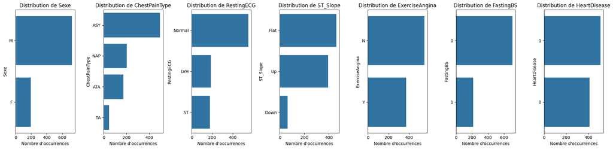

```python
#Distribution des variables qualitatives
fig, axes = plt.subplots(1, len(categorical_vars), figsize=(20, 5), sharey=False)

for i, var in enumerate(categorical_vars):
    sns.countplot(y=var, data=data, order=data[var].value_counts().index, ax=axes[i])
    axes[i].set_title(f"Distribution de {var}")
    axes[i].set_xlabel("Nombre d'occurrences")
    axes[i].set_ylabel(var)
plt.tight_layout()
plt.show()
```

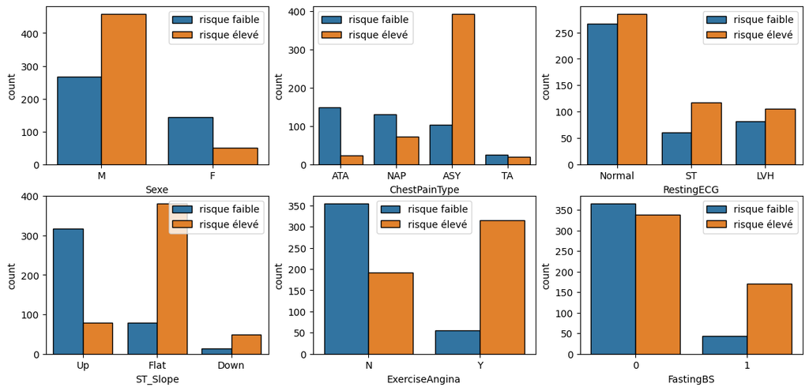

```python
# variables catégorielles vs variable cible
plt.figure(figsize=(14, 10))
for i, col in enumerate([col for col in categorical_vars if col != 'HeartDisease']):
    plt.subplot(3, 3, i+1)
    sns.countplot(x=col, hue='HeartDisease', data=data, edgecolor='black')
    plt.legend(['risque faible', 'risque élevé'])
```

- Sexe : Les hommes ont une proportion plus élevée de cardiopathie que les femmes, où le risque est plus faible.
- ChestPainType : Le type de douleur thoracique "ASY" est fortement associé à un risque élevé de cardiopathie.
- ExerciseAngina : La présence d'angine d'effort ("Yes") est liée à un risque accru de cardiopathie.
- ST_Slope : Les segments ST "Flat" et "Down" indiquent un risque plus élevé de cardiopathie.

### Variables numériques:

```python
print("\nListe des variables numériques :")
numerical_vars = [col for col in data.select_dtypes(include=["float64", "int64"]).columns if col not in categorical_vars]
print(numerical_vars)
```

```
Liste des variables numériques :
['Age', 'RestingBP', 'Cholesterol', 'MaxHR', 'Oldpeak']
```

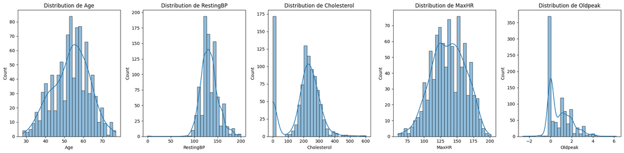

```python
#Distribution des variables quantitatives
fig, axes = plt.subplots(1, len(numerical_vars), figsize=(20,5), sharey=False)
for i, var in enumerate(numerical_vars):
    sns.histplot(data[var], kde=True, bins=30, ax=axes[i])
    axes[i].set_title(f"Distribution de {var}")
    axes[i].set_xlabel(var)

plt.tight_layout()
plt.show()
```

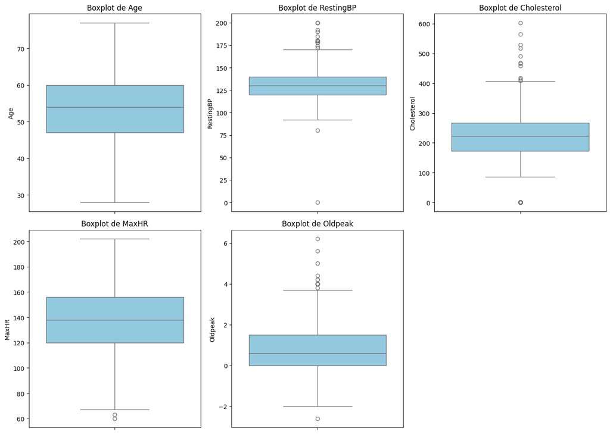

```python
#Boxplots des variables numériques
plt.figure(figsize=(14, 10))
for i, col in enumerate(numerical_vars):
    plt.subplot((len(numerical_vars) + 2) // 3, 3, i + 1)
    sns.boxplot(y=data[col], color='skyblue')
    plt.title(f"Boxplot de {col}")
plt.tight_layout()
plt.show()
```

On remarque la présence des valeurs abhérentes pour les variables: RestingBP, Cholesterol, MaxHR et Oldpeak.

```python
# Calcul des statistiques descriptives par classe de HeartDisease
stats_by_class = (
    data.groupby('HeartDisease')
    .agg({col: ['mean'] for col in numerical_vars})
)

print("Statistiques descriptives par classe de HeartDisease :")
print(stats_by_class)
```

```
Statistiques descriptives par classe de HeartDisease :
                    Age   RestingBP Cholesterol       MaxHR   Oldpeak
                   mean        mean        mean        mean      mean
HeartDisease
0             50.551220  130.180488  227.121951  148.151220  0.408049
1             55.899606  134.185039  175.940945  127.655512  1.274213
```

Les variables Age, RestingBP, et Oldpeak augmentent en moyenne avec le risque élevé de cardiopathie.

### Valeurs manquantes:

```python
print("\nValeurs manquantes :")
print(data.isnull().sum())
```

```
Valeurs manquantes :
Age               0
Sexe              0
ChestPainType     0
RestingBP         0
Cholesterol       0
FastingBS         0
RestingECG        0
MaxHR             0
ExerciseAngina    0
Oldpeak           0
ST_Slope          0
HeartDisease      0
dtype: int64
```

On a pas de valeurs manquantes.

## Préparation des données

### Gestion des valeurs aberrantes( remplacer les outliers par la valeur du quantile) :

```python
# Liste des variables représentant des valeurs aberrantes
L = ['RestingBP', 'Cholesterol', 'MaxHR', 'Oldpeak']
# Boucle pour remplacer les valeurs aberrantes par Q1 ou Q3
for var in L:
    Q1 = data[var].quantile(0.25)
    Q3 = data[var].quantile(0.75)
    IQR = Q3 - Q1
    lower_bound = Q1 - 1.5 * IQR
    upper_bound = Q3 + 1.5 * IQR
    # Remplacer les outliers par Q1 ou Q3
    data.loc[data[var] < lower_bound, var] = Q1
    data.loc[data[var] > upper_bound, var] = Q3
```

### Encodage des variables catégorielles:

On code les variables catégorielles en valeurs numériques sans attribuer d'ordre entre les catégories, et pour cela on utilise le one-hot encoding.

```python
# Liste des colonnes catégorielles à encoder
categorical_vars = ['RestingECG', 'ST_Slope', 'ExerciseAngina', 'FastingBS', 'ChestPainType', 'Sexe']
# Appliquer le One-Hot Encoding
data = pd.get_dummies(data, columns=categorical_vars, drop_first=True)
# Vérifier la forme des données après l'encodage
print(data.shape)
```

```
(918, 16)
```

- RestingECG (3 catégories : normal, ST, LVH) → 2 colonnes
- ST_Slope (3 catégories : up, flat, down) → 2 colonnes
- ExerciseAngina (2 catégories : yes, no) → 1 colonne
- FastingBS (2 catégories : 0, 1) → 1 colonne
- ChestPainType (4 catégories : ATA, NAP, ASY, TA) → 3 colonnes
- Sexe (2 catégories : M, F) → 1 colonne

Les nouvelles variables font un total de 10 colonnes. On a en plus: 5 variables numériques et la varible cible HeartDisease.

C'est ainsi qu'on a 16 colonnes.

### Normalisation des variables numériques:

La normalisation des variables numériques est utile car elle met toutes les variables sur la même échelle, ce qui permet d'améliorer la convergence des algorithmes d'apprentissage automatique en empêchant les variables à grande échelle d'avoir un impact disproportionné sur le modèle.

```python
scaler = StandardScaler()
data[numerical_vars] = scaler.fit_transform(data[numerical_vars])
```

```python
data.head()
```

|  | Age | RestingBP | Cholesterol | MaxHR | Oldpeak | HeartDisease | RestingECG_Normal | RestingECG_ST | ST_Slope_Flat | ST_Slope_Up | ExerciseAngina_Y | FastingBS_1 | ChestPainType_ATA | ChestPainType_NAP | ChestPainType_TA | Sexe_M |
| --- | --- | --- | --- | --- | --- | --- | --- | --- | --- | --- | --- | --- | --- | --- | --- | --- |
| 0 | -1.433140 | 0.552727 | 1.138782 | 1.390607 | -0.877578 | 0 | True | False | False | True | False | False | True | False | False | True |
| 1 | -0.478484 | 1.829372 | -0.917944 | 0.756047 | 0.162867 | 1 | True | False | True | False | False | False | False | True | False | False |
| 2 | -1.751359 | -0.085596 | 1.025567 | -1.544236 | -0.877578 | 0 | False | True | False | True | False | False | True | False | False | True |
| 3 | -0.584556 | 0.425062 | -0.276396 | -1.147635 | 0.683090 | 1 | True | False | True | False | True | False | False | False | False | False |
| 4 | 0.051881 | 1.191049 | -0.634908 | -0.592395 | -0.877578 | 0 | True | False | False | True | False | False | False | True | False | True |

La moyenne de l'age (comme exemple) est de 53.510893, après normalisation, un âge inférieur à cette moyenne sera transformé en une valeur négative.

### Séparation des ensembles de données:

```python
X, y = data.drop('HeartDisease', axis=1), data['HeartDisease']
X_train, X_test, y_train, y_test = train_test_split(X, y, test_size=0.2, random_state=1234)

print(f'X_train shape: {X_train.shape}')
print(f'X_test shape: {X_test.shape}')
```

```
X_train shape: (734, 15)
X_test shape: (184, 15)
```

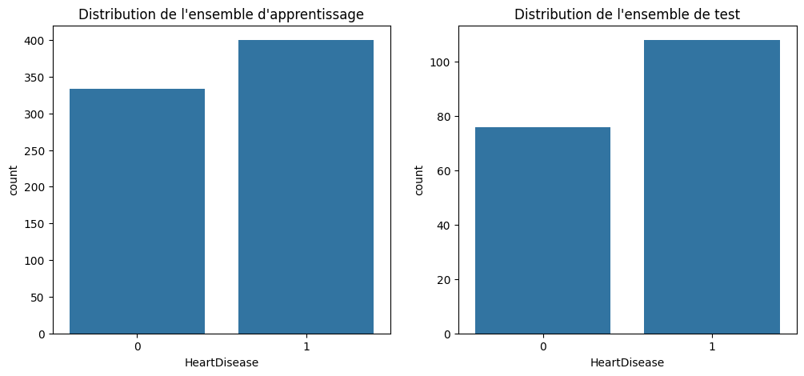

```python
plt.figure(figsize=(12, 5))
#distribution pour l'ensemble d'apprentissage
plt.subplot(1, 2, 1)
sns.countplot(x=y_train)
plt.title('Distribution de l\'ensemble d\'apprentissage')
#distribution pour l'ensemble de test
plt.subplot(1, 2, 2)
sns.countplot(x=y_test)
plt.title('Distribution de l\'ensemble de test')
plt.show()
```

La proportion des classes est similaire dans les ensembles d'apprentissage et de test.

## Création du réseau de neurones

### Définir l'architecture du modèle:

```python
model = keras.Sequential([
    layers.Dense(X_train.shape[1], activation='relu', input_shape=(X_train.shape[1],)),
    layers.Dense(64, activation='relu'),
    layers.Dense(32, activation='relu'),
    layers.Dense(16, activation='relu'),
    layers.Dense(8, activation='relu'),
    layers.Dense(1, activation='sigmoid')
])
model.compile(optimizer='adam',
              loss='binary_crossentropy',
              metrics=['accuracy'])

# Afficher un résumé du modèle
model.summary()
```

```
Model: "sequential"
```

```
┏━━━━━━━━━━━━━━━━━━━━━━━━━━━━━━━━━━━━━━┳━━━━━━━━━━━━━━━━━━━━━━━━━━━━━┳━━━━━━━━━━━━━━━━━┓
┃ Layer (type)                         ┃ Output Shape                ┃         Param # ┃
┡━━━━━━━━━━━━━━━━━━━━━━━━━━━━━━━━━━━━━━╇━━━━━━━━━━━━━━━━━━━━━━━━━━━━━╇━━━━━━━━━━━━━━━━━┩
│ dense (Dense)                        │ (None, 15)                  │             240 │
├──────────────────────────────────────┼─────────────────────────────┼─────────────────┤
│ dense_1 (Dense)                      │ (None, 64)                  │           1,024 │
├──────────────────────────────────────┼─────────────────────────────┼─────────────────┤
│ dense_2 (Dense)                      │ (None, 32)                  │           2,080 │
├──────────────────────────────────────┼─────────────────────────────┼─────────────────┤
│ dense_3 (Dense)                      │ (None, 16)                  │             528 │
├──────────────────────────────────────┼─────────────────────────────┼─────────────────┤
│ dense_4 (Dense)                      │ (None, 8)                   │             136 │
├──────────────────────────────────────┼─────────────────────────────┼─────────────────┤
│ dense_5 (Dense)                      │ (None, 1)                   │               9 │
└──────────────────────────────────────┴─────────────────────────────┴─────────────────┘
```

```
 Total params: 4,017 (15.69 KB)
```

```
 Trainable params: 4,017 (15.69 KB)
```

```
 Non-trainable params: 0 (0.00 B)
```

Pour limiter le risque de surapprentissage on implémente un mécanisme d'arrêt précoce pour arrêter l'entraînement si la performance sur un jeu de validation cesse de s'améliorer.

```python
early_stopping = keras.callbacks.EarlyStopping(patience=5, restore_best_weights=True)
```

### Entraînement du modèle:

```python
history = model.fit(X_train, y_train,validation_split=0.2,epochs=100,batch_size=32,callbacks=[early_stopping],verbose=1)
```

```
19/19 ━━━━━━━━━━━━━━━━━━━━ 3s 14ms/step - accuracy: 0.5554 - loss: 0.6763 - val_accuracy: 0.5578 - val_loss: 0.6531
19/19 ━━━━━━━━━━━━━━━━━━━━ 0s 4ms/step - accuracy: 0.6225 - loss: 0.5950 - val_accuracy: 0.6463 - val_loss: 0.6194
19/19 ━━━━━━━━━━━━━━━━━━━━ 0s 4ms/step - accuracy: 0.7990 - loss: 0.5324 - val_accuracy: 0.7007 - val_loss: 0.6020
19/19 ━━━━━━━━━━━━━━━━━━━━ 0s 4ms/step - accuracy: 0.8470 - loss: 0.4338 - val_accuracy: 0.7143 - val_loss: 0.6034
19/19 ━━━━━━━━━━━━━━━━━━━━ 0s 4ms/step - accuracy: 0.8542 - loss: 0.3946 - val_accuracy: 0.7415 - val_loss: 0.6084
19/19 ━━━━━━━━━━━━━━━━━━━━ 0s 4ms/step - accuracy: 0.8485 - loss: 0.3718 - val_accuracy: 0.7415 - val_loss: 0.5991
19/19 ━━━━━━━━━━━━━━━━━━━━ 0s 4ms/step - accuracy: 0.8711 - loss: 0.3306 - val_accuracy: 0.7279 - val_loss: 0.5744
19/19 ━━━━━━━━━━━━━━━━━━━━ 0s 4ms/step - accuracy: 0.8629 - loss: 0.3355 - val_accuracy: 0.7279 - val_loss: 0.5760
19/19 ━━━━━━━━━━━━━━━━━━━━ 0s 3ms/step - accuracy: 0.8628 - loss: 0.3325 - val_accuracy: 0.7415 - val_loss: 0.6031
19/19 ━━━━━━━━━━━━━━━━━━━━ 0s 5ms/step - accuracy: 0.8704 - loss: 0.3068 - val_accuracy: 0.7415 - val_loss: 0.5842
19/19 ━━━━━━━━━━━━━━━━━━━━ 0s 3ms/step - accuracy: 0.8958 - loss: 0.2734 - val_accuracy: 0.7211 - val_loss: 0.6401
19/19 ━━━━━━━━━━━━━━━━━━━━ 0s 3ms/step - accuracy: 0.8896 - loss: 0.2783 - val_accuracy: 0.7347 - val_loss: 0.5832
```

Les résultats montrent une amélioration rapide de l'accuracy d'entraînement (55 % à 88,9 %) et une stabilité de l'accuracy de validation.

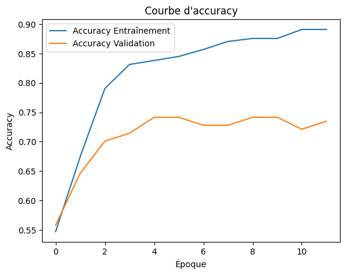

```python
# Tracer l'accuracy
plt.plot(history.history['accuracy'], label='Accuracy Entraînement')
plt.plot(history.history['val_accuracy'], label='Accuracy Validation')
plt.xlabel('Époque')
plt.ylabel('Accuracy')
plt.legend()
plt.title('Courbe d\'accuracy')
plt.show()
```

## Analyse de la performance du modèle:

### Erreurs de classification:

```python
model.evaluate(X_test, y_test)
y_pred = (model.predict(X_test) > 0.5).astype("int32")
# Rapport détaillé des performances
print(classification_report(y_test, y_pred))
```

```
6/6 ━━━━━━━━━━━━━━━━━━━━ 0s 4ms/step - accuracy: 0.8557 - loss: 0.3577
6/6 ━━━━━━━━━━━━━━━━━━━━ 0s 37ms/step
              precision    recall  f1-score   support

           0       0.86      0.80      0.83        76
           1       0.87      0.91      0.89       108

    accuracy                           0.86       184
   macro avg       0.86      0.86      0.86       184
weighted avg       0.86      0.86      0.86       184
```

Le modèle atteint une précision globale de 85 %, avec des scores de précision, rappel et F1 équilibrés pour les deux classes, ce qui indique une performance satisfaisante et bien équilibrée sur les données de test.

### Matrice de confusion:

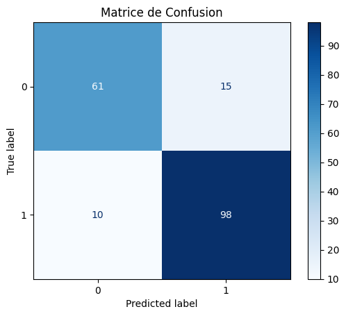

```python
conf_matrix = confusion_matrix(y_test, y_pred)
disp = ConfusionMatrixDisplay(confusion_matrix=conf_matrix, display_labels=[0, 1])
disp.plot(cmap="Blues")
plt.title("Matrice de Confusion")
plt.show()
```

### Courbe ROC

```
6/6 ━━━━━━━━━━━━━━━━━━━━ 0s 3ms/step
```

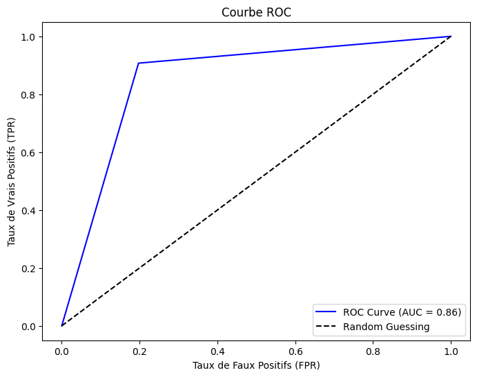

```python
# Calculer les scores de probabilité
y_prob = model.predict(X_test)
# Courbe ROC
fpr, tpr, thresholds = roc_curve(y_test, y_pred)
auc_score = roc_auc_score(y_test, y_pred)
# Tracer la courbe ROC
plt.figure(figsize=(8, 6))
plt.plot(fpr, tpr, label=f"ROC Curve (AUC = {auc_score:.2f})", color='blue')
plt.plot([0, 1], [0, 1], 'k--', label='Random Guessing')
plt.title("Courbe ROC")
plt.xlabel("Taux de Faux Positifs (FPR)")
plt.ylabel("Taux de Vrais Positifs (TPR)")
plt.legend()
plt.show()
```

Un AUC de 0.86 (proche de 1) indique que le modèle a une bonne capacité discriminante pour distinguer entre les classes positives et négatives.

## Conclusions sur le modèle et recommandations:

Le modèle montre une performance globale satisfaisante avec une précision élevé et des scores équilibrés entre les classes, ce qui suggère une bonne capacité de généralisation. Cependant, pour une amélioration continue, il serait pertinent de tester différentes configurations d'hyperparamètres, telles que le taux d'apprentissage, la taille du lot, et la régularisation, pour maximiser les performances.

## Comparaison avec un modèle de régression logistique:

```python
# Logistic regression model
logistic_model = LogisticRegression()
logistic_model.fit(X_train, y_train)

# Make predictions
y_pred = logistic_model.predict(X_test)

print("Classification report:")
print(classification_report(y_test, y_pred))

# Compute the AUC score
print("AUC Score: ", roc_auc_score(y_test, y_pred))
```

```
Classification report:
              precision    recall  f1-score   support

           0       0.88      0.83      0.85        76
           1       0.88      0.92      0.90       108

    accuracy                           0.88       184
   macro avg       0.88      0.87      0.88       184
weighted avg       0.88      0.88      0.88       184

AUC Score:  0.8728070175438596
```

La régression logistique semble avoir une performance légèrement meilleure que le réseau de neurones, notamment pour la classe 0 et l'AUC. Le réseau de neurones offre des performances compétitives, notamment pour la classe 1, et pourrait être amélioré par un ajustement des hyperparamètres ou l'utilisation de techniques avancées comme le réglage de l'architecture du réseau ou la régularisation.

# Problème V : Analyse d’une série temporelle

```python
data = pd.read_csv("Danube ammonium level Time Series.csv", sep = ";", index_col="Months")
data
#data.info()
```

| Months | Ammonium |
| --- | --- |
| 01/01/1996 | 0,253333 |
| 01/02/1996 | 0,218889 |
| 01/03/1996 | 0,242 |
| 01/04/1996 | 0,134545 |
| 01/05/1996 | 0,113333 |
| ... | ... |
| 01/08/2017 | 0,031222 |
| 01/09/2017 | 0,045875 |
| 01/10/2017 | 0,032474 |
| 01/11/2017 | 0,047125 |
| 01/12/2017 | 0,056563 |

264 rows × 1 columns

## Analyse descriptive

```python
print(data[['Ammonium']].describe())
# Vérification des valeurs manquantes
print("\nValeurs manquantes :")
print(data.isnull().sum())
```

```
        Ammonium
count        264
unique       258
top     0,153636
freq           2

Valeurs manquantes :
Ammonium    0
dtype: int64
```

```python
# Remplace les virgules par des points pour convertir en float
data['Ammonium'] = data['Ammonium'].str.replace(',', '.').astype(float)

# Vérification après transformation
print(data['Ammonium'].head())
```

```
Months
01/01/1996    0.253333
01/02/1996    0.218889
01/03/1996    0.242000
01/04/1996    0.134545
01/05/1996    0.113333
Name: Ammonium, dtype: float64
```

## Visualisation de la série temporelle

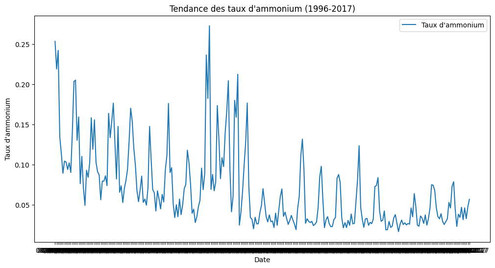

```python
plt.figure(figsize=(12, 6))
#plt.plot(data['Months'], data['Ammonium'], label='Taux d\'ammonium')
plt.plot(data['Ammonium'], label='Taux d\'ammonium')
plt.title("Tendance des taux d'ammonium (1996-2017)")
plt.xlabel("Date")
plt.ylabel("Taux d'ammonium")
plt.legend()
plt.show()
```

La série montre une tendance globale décroissante au fil des années, avec des taux d'ammonium plus élevés au début de la période (1996) et une stabilisation après. Nous remarquons des pics périodiques ce qui montre la saisonalité des données. Ces fluctuations pourraient être liées à des facteurs environnementaux.

## Préparation des données

### Données d'apprentissage et données test

```python
train_data = data.iloc[:252]
test_data = data.iloc[-13:]
```

### Normalisation des données

```python
scaler = MinMaxScaler(feature_range=(0, 1))
train_data_sc = scaler.fit_transform(train_data)
test_data_sc = scaler.transform(test_data)
```

## Préparation des données pour RNN

Nous allons définir les différents fontions et paramètres que nous allons utiliser pour appliquer le M0dèle RNN.

```python
def split_sequence(sequence, n_steps):
    X, y = list(), list()
    for i in range(len(sequence)):
        end_ix = i + n_steps
        if end_ix > len(sequence) - 1:  # Arrêter si on dépasse la taille
            break
        seq_x, seq_y = sequence[i:end_ix], sequence[end_ix]
        X.append(seq_x)
        y.append(seq_y)
    return np.array(X), np.array(y)
```

```python
def rmse(test, prediction):
    rmse = np.sqrt(mean_squared_error(test, prediction))
    print("The root mean squared error is {:.2f}.".format(rmse))
```

```python
n_steps = 1
train_X, train_y = split_sequence(train_data_sc, n_steps)
test_X, test_y = split_sequence(test_data_sc, n_steps)
```

```python
# Reshaper les données pour les RNN
train_X = train_X.reshape((train_X.shape[0], train_X.shape[1], 1))
test_X = test_X.reshape((test_X.shape[0], test_X.shape[1], 1))

# Vérifier les dimensions
print(f"Train_X shape: {train_X.shape}")
print(f"Train_y shape: {train_y.shape}")
print(f"Test_X shape: {test_X.shape}")
print(f"Test_y shape: {test_y.shape}")
```

```
Train_X shape: (251, 1, 1)
Train_y shape: (251, 1)
Test_X shape: (12, 1, 1)
Test_y shape: (12, 1)
```

## Modèle RNN

Après plusieurs test avec differents paramètres, nous estimons que le meilleur modèle est les suivant.

```
13/13 ━━━━━━━━━━━━━━━━━━━━ 2s 25ms/step - loss: 0.0607 - mae: 0.1729 - val_loss: 0.0139 - val_mae: 0.0851
13/13 ━━━━━━━━━━━━━━━━━━━━ 0s 6ms/step - loss: 0.0255 - mae: 0.1222 - val_loss: 0.0132 - val_mae: 0.0796
13/13 ━━━━━━━━━━━━━━━━━━━━ 0s 5ms/step - loss: 0.0225 - mae: 0.1041 - val_loss: 0.0135 - val_mae: 0.0737
13/13 ━━━━━━━━━━━━━━━━━━━━ 0s 5ms/step - loss: 0.0170 - mae: 0.0911 - val_loss: 0.0126 - val_mae: 0.0736
13/13 ━━━━━━━━━━━━━━━━━━━━ 0s 6ms/step - loss: 0.0241 - mae: 0.1009 - val_loss: 0.0129 - val_mae: 0.0701
13/13 ━━━━━━━━━━━━━━━━━━━━ 0s 6ms/step - loss: 0.0178 - mae: 0.0928 - val_loss: 0.0127 - val_mae: 0.0698
13/13 ━━━━━━━━━━━━━━━━━━━━ 0s 7ms/step - loss: 0.0191 - mae: 0.0923 - val_loss: 0.0123 - val_mae: 0.0708
13/13 ━━━━━━━━━━━━━━━━━━━━ 0s 6ms/step - loss: 0.0152 - mae: 0.0842 - val_loss: 0.0127 - val_mae: 0.0686
13/13 ━━━━━━━━━━━━━━━━━━━━ 0s 7ms/step - loss: 0.0223 - mae: 0.0970 - val_loss: 0.0121 - val_mae: 0.0745
13/13 ━━━━━━━━━━━━━━━━━━━━ 0s 6ms/step - loss: 0.0200 - mae: 0.0996 - val_loss: 0.0129 - val_mae: 0.0704
13/13 ━━━━━━━━━━━━━━━━━━━━ 0s 6ms/step - loss: 0.0230 - mae: 0.0988 - val_loss: 0.0122 - val_mae: 0.0675
13/13 ━━━━━━━━━━━━━━━━━━━━ 0s 5ms/step - loss: 0.0199 - mae: 0.0972 - val_loss: 0.0117 - val_mae: 0.0703
13/13 ━━━━━━━━━━━━━━━━━━━━ 0s 8ms/step - loss: 0.0170 - mae: 0.0946 - val_loss: 0.0123 - val_mae: 0.0673
13/13 ━━━━━━━━━━━━━━━━━━━━ 0s 7ms/step - loss: 0.0207 - mae: 0.0974 - val_loss: 0.0119 - val_mae: 0.0687
13/13 ━━━━━━━━━━━━━━━━━━━━ 0s 7ms/step - loss: 0.0191 - mae: 0.0920 - val_loss: 0.0121 - val_mae: 0.0676
13/13 ━━━━━━━━━━━━━━━━━━━━ 0s 9ms/step - loss: 0.0190 - mae: 0.0910 - val_loss: 0.0117 - val_mae: 0.0675
13/13 ━━━━━━━━━━━━━━━━━━━━ 0s 6ms/step - loss: 0.0155 - mae: 0.0856 - val_loss: 0.0120 - val_mae: 0.0674
13/13 ━━━━━━━━━━━━━━━━━━━━ 0s 6ms/step - loss: 0.0197 - mae: 0.0976 - val_loss: 0.0117 - val_mae: 0.0691
13/13 ━━━━━━━━━━━━━━━━━━━━ 0s 6ms/step - loss: 0.0168 - mae: 0.0940 - val_loss: 0.0119 - val_mae: 0.0695
13/13 ━━━━━━━━━━━━━━━━━━━━ 0s 5ms/step - loss: 0.0147 - mae: 0.0851 - val_loss: 0.0124 - val_mae: 0.0680
1/1 ━━━━━━━━━━━━━━━━━━━━ 0s 182ms/step
```

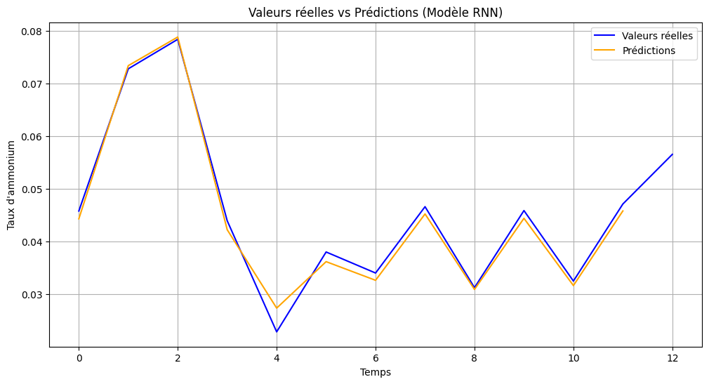

```
RMSE du modèle RNN : 0.017490683494256684
```

```python
import tensorflow as tf
from tensorflow.keras import Sequential
from tensorflow.keras.layers import SimpleRNN, Dense, Dropout
from sklearn.model_selection import train_test_split
import matplotlib.pyplot as plt
import numpy as np

# Construction du modèle RNN
def build_rnn_model():
    model = Sequential()
    model.add(SimpleRNN(units=64, input_shape=(train_X.shape[1], train_X.shape[2]), activation='relu'))
    model.add(Dense(128, activation='relu'))
    model.add(Dropout(0.3))
    model.add(Dense(64, activation='relu'))
    model.add(Dense(1, activation='linear'))

    model.compile(optimizer=tf.keras.optimizers.Adam(learning_rate=0.001),
                  loss='mean_squared_error',
                  metrics=['mae'])

    return model


model = build_rnn_model()

# Résumé du modèle
#model.summary()
train_X, val_X, train_y, val_y = train_test_split(train_X, train_y, test_size=0.2)
# Entraînement
history = model.fit(train_X, train_y,
                    validation_data=(val_X, val_y),
                    epochs=20,
                    batch_size=16,
                    verbose=1)

# Prédictions
predictions = model.predict(test_X)
predictions = scaler.inverse_transform(predictions)

# plot
plt.figure(figsize=(12, 6))
plt.plot(scaler.inverse_transform(test_data_sc), label='Valeurs réelles', color='blue')
plt.plot(predictions, label='Prédictions', color='orange')
plt.title("Valeurs réelles vs Prédictions (Modèle RNN)")
plt.xlabel("Temps")
plt.ylabel("Taux d'ammonium")
plt.legend()
plt.grid()
plt.show()

# Évaluation avec la RMSE
rmse = np.sqrt(np.mean((scaler.inverse_transform(test_data_sc[1:]) - predictions) ** 2))
print(f"RMSE du modèle RNN : {rmse}")
```

Nous avons choisi un modèle composé de 5 couches principales:

- Une couche RNN avec 64 unités.
- Une première couche Dense avec 128 neurones.
- Une couche Dropout pour réduire le surapprentissage (30% des neurones abandonnés).
- Une deuxième couche Dense avec 64 neurones.
- Une couche de sortie linéaire pour prédire les valeurs continues.

## Modèle ARIMA

Nous allons utilisé la fonction auto_arima pour trouvé le modèle le plus adéquat pour notre data. Pour le paramètre de saisonalité, nous avons pris m=12 pour la saisonalité anuelle.

```python
!pip install pmdarima
import pandas as pd
import numpy as np
from sklearn.metrics import mean_squared_error
from pmdarima import auto_arima
import matplotlib.pyplot as plt

model = auto_arima(train_data_sc, seasonal=True, m=12)
print(model.summary())
```

```
Downloading pmdarima-2.0.4-cp310-cp310-manylinux_2_17_x86_64.manylinux2014_x86_64.manylinux_2_28_x86_64.whl (2.1 MB)
   ━━━━━━━━━━━━━━━━━━━━━━━━━━━━━━━━━━━━━━━━ 2.1/2.1 MB 22.2 MB/s eta 0:00:00
                                        SARIMAX Results
===============================================================================================
Dep. Variable:                                       y   No. Observations:                  252
Model:             SARIMAX(2, 1, 1)x(1, 0, [1, 2], 12)   Log Likelihood                 182.523
Date:                                 Sun, 01 Dec 2024   AIC                           -349.046
Time:                                         18:46:38   BIC                           -320.843
Sample:                                              0   HQIC                          -337.697
                                                 - 252
Covariance Type:                                   opg
==============================================================================
                 coef    std err          z      P>|z|      [0.025      0.975]
------------------------------------------------------------------------------
intercept  -7.016e-05      0.000     -0.482      0.630      -0.000       0.000
ar.L1          0.3206      0.066      4.892      0.000       0.192       0.449
ar.L2          0.1452      0.052      2.774      0.006       0.043       0.248
ma.L1         -0.9020      0.041    -21.970      0.000      -0.982      -0.822
ar.S.L12       0.9382      0.071     13.239      0.000       0.799       1.077
ma.S.L12      -0.6356      0.102     -6.225      0.000      -0.836      -0.436
ma.S.L24      -0.1600      0.086     -1.852      0.064      -0.329       0.009
sigma2         0.0134      0.001     17.363      0.000       0.012       0.015
===================================================================================
Ljung-Box (L1) (Q):                   0.67   Jarque-Bera (JB):               245.39
Prob(Q):                              0.41   Prob(JB):                         0.00
Heteroskedasticity (H):               0.21   Skew:                             0.55
Prob(H) (two-sided):                  0.00   Kurtosis:                         7.72
===================================================================================

Warnings:
[1] Covariance matrix calculated using the outer product of gradients (complex-step).
```

La fonction auto_arima a retourné le model **SARIMAX(2, 1, 1)x(1, 0, [1, 2], 12)** :

- p=2 : Ordre d'auto-régression (AR).
- d=1 : 1 différenciation pour rendre la série stationnaire.
- q=1 : Ordre de la moyenne mobile (MA).
- m=12 : Saisonalité anuelle.

Le modèle obtenu montre une forte composante saisonnière annuelle (S.L12=0.9382), donc la série chronologique est influencée par des cycles saisonniers. Les resultats des AR et MA montrent une dépendance à court terme et des effets résiduels bien capturés. AIC (-349.046) et BIC (-320.843) indiquent un ajustement correct.

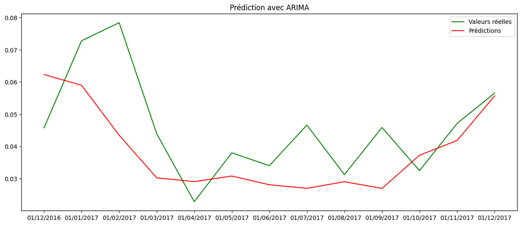

```
RMSE du modèle ARIMA : 0.014686225009785338
```

```python
pred2 = model.predict(test_data_sc.shape[0])
pred2 = scaler.inverse_transform(pred2.reshape(-1,1))

plt.figure(figsize=(15, 6))
plt.plot(test_data.index, test_data, label='Valeurs réelles', color='green')
plt.plot(test_data.index, pred2, label='Prédictions', color='red')
plt.title('Prédiction avec ARIMA')
plt.legend()
plt.show()

rmse2 = np.sqrt(np.mean((test_data - pred2) ** 2))
print(f"RMSE du modèle ARIMA : {rmse2}")
```

Le modèle arrive plus ou moins à capturer la tendance globale de la série, mais il montre des limites dans la capture des variations rapides et des amplitudes des fluctuations. De plus le RMSE est relativement faible.

## Conclusion

Malgré un décalage initial observé lors des tests, les ajustements ont permis de réduire ce problème. Il s'est bien adapté aux variations des données, mais il reste sensible aux hyperparamètres et à la quantité de données utilisées pour l'entraînement.

- **ARIMA**, a donné des prédictions étaient parfois décalées ou lissées, ce qui peut limiter la précision dans des environnements dynamiques.

Le choix entre ARIMA et RNN dépend largement de la nature des données et des objectifs de l’analyse. ARIMA est idéal pour des séries temporelles simples et bien structurées, tandis que RNN excelle pour des données complexes et non linéaires. Une combinaison des deux pourrait fournir un compromis optimal entre précision et efficacité.